# Manipulating image data

Mahbubul Majumder, PhD  
Nov 18, 2014

### What is image data?

- We used data to create image.
- Some times image itself could be data
  - Magnetic Resonance Imaging (MRI)
  - digital pictures taken by a traffic camera
  - google earth or satellite imagery
- Every image can be expressed as a two dimensional layout of colors
  - chopped into small (really tiny) rectangles
  - the color of each piece is recorded in a two dimensional matrix
  - this generates image data
  - videos can be considered as the time series of image data

### Types of image

- **Vector image** based on specific shapes like circle, rectangle, line and texts
  - uses mathematical equation or formula
  - can be scaled to any size without distortion
  - examples: SVG, pdf
  - usually data are visualized using these types of plots
- **Raster image** based on pixels
  - uses an array of square or rectangular region of color
  - can't scale larger than some specific size
  - example JPEG, BMP, PNG
  - usually captured by digital camera or medical scans, not generated from data

### Vector vs Raster image

- Vector image can be scaled to any size

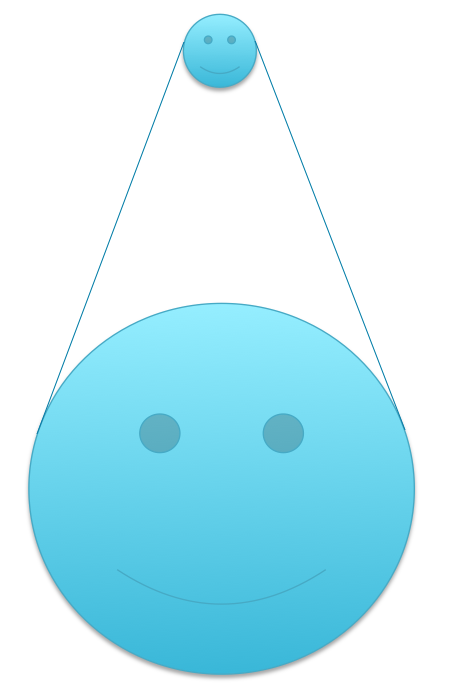

- Raster image distorts when enlarged

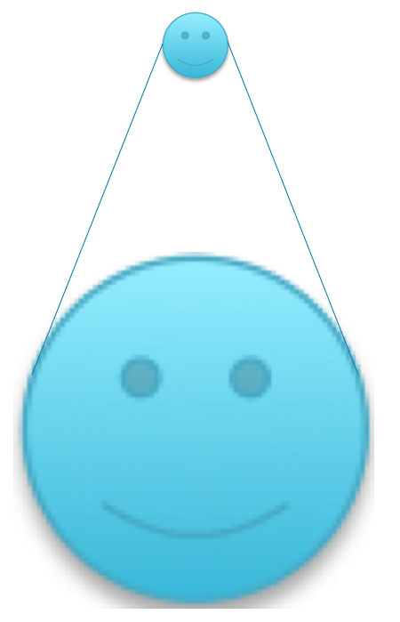

### Raster image

- Array of colors
  - first two dimensions are locations
  - third dimension is color values
  - a fourth dimension often store transparency
- Vector images are not always preferred
  - for big data, many shapes may be plotted
  - file size gets much bigger for large data
  - raster image can be used to solve it

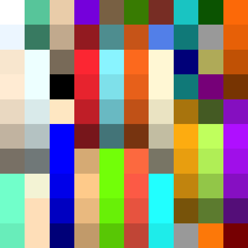

### Bangladesh map

[figure not shown]

```r
library(maps)
par(mar=rep(0, 4))
map(region="Bangladesh", col="black", fill=TRUE)
```

### Bangladesh flag

- Bangladesh flag taken from [wikipedia](http://upload.wikimedia.org/wikipedia/commons/f/f9/Flag_of_Bangladesh.svg) and saved as png file

[figure not shown]

```r
library(png)
bdFlag <- readPNG("bangladesh-flag.png")
flagRaster <- as.raster(bdFlag)

library(grid)
grid.raster(flagRaster)
```

### Bangladesh flag with map overlaid

[figure not shown]

```r
bdFlag <- readPNG("bangladesh-flag.png")
bdMap <- readPNG("bangladesh-map.png")

flagRaster <- as.raster(bdFlag)
mapRaster <- as.raster(bdMap)

grid.raster(flagRaster)
grid.raster(mapRaster)
```

### Raster image as array

- Raster images are like arrays, we can subset like a matrix so the dimensions are same

```r
dm <- dim(mapRaster)
flagRaster <- flagRaster[1:dm[1], 134:(dm[2] + 133)]

dim(flagRaster)
```

```
[1] 600 686
```

```r
dim(mapRaster)
```

```
[1] 600 686
```

```r
flagRaster[1:3,1:5]
```

```
     [,1]        [,2]        [,3]        [,4]        [,5]
[1,] "#036A4EFF" "#036A4EFF" "#036A4EFF" "#036A4EFF" "#036A4EFF"
[2,] "#036A4EFF" "#036A4EFF" "#036A4EFF" "#036A4EFF" "#036A4EFF"
[3,] "#036A4EFF" "#036A4EFF" "#036A4EFF" "#036A4EFF" "#036A4EFF"
```

### Manipulating the raster image

[figure not shown]

```r
indx <- mapRaster =="#00000000"
flagRaster[indx] <- "transparent"

grid.raster(flagRaster)
```

### Digital postmortem

- Virtual Autopsy, getting widely used
  - provides convenience and easy to re-examine the evidence
  - some features are not possible to get in traditional autopsy
  - 3D structures can be examined
  - even soft tissues can be segmented
  - generates huge amount of data

A full body MRI scan taken from Beautiful Visualization edited by Julie at el.

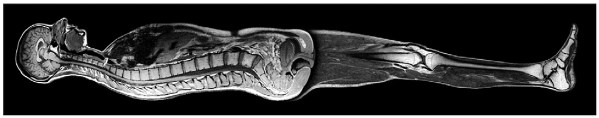

### Case study: bullet holes

[figure not shown]

```r
bulletHole <- readPNG("bullet-hole.png")
bulletHole <- as.raster(bulletHole)
grid.raster(bulletHole)
```

Picture source:  
https://www.demongraphics.co.uk/index.php?main_page=product_info&cPath=68&products_id=802

### How many bullet holes are there?

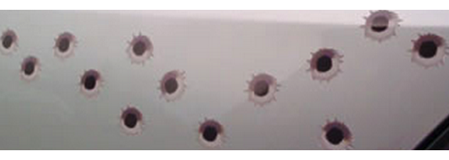

```r
holes <- bulletHole[270:470, 250:890]
grid.raster(holes)
```

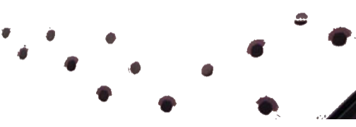

```r
indx <- as.matrix(holes) > "#857C7DFF"
bholes <- holes
bholes[indx] <- "transparent"
grid.raster(bholes)
```

### High level view of the bullet holes

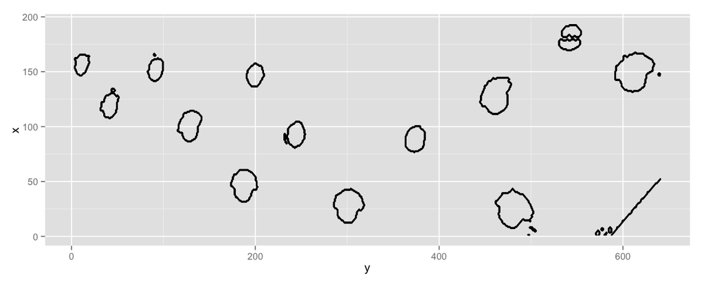

```r
dm <- dim(holes)
cl <- matrix(1,ncol=dm[2], nrow=dm[1])
cl[indx] <- 0
x <- dm[1]:1
y <- 1:dm[2]
dat <- data.frame(expand.grid(x,y), z = as.vector(cl))
names(dat) <- c("x","y","z")

ggplot(dat, aes(y, x, z = z)) + stat_contour()
```

### Digital investigation

- Often we have low resolution image to investigate
- This bullet case study provides critical information that can be computed
  - relative distances of bullet holes, adjusting the units and camera angles
  - measurements would be quite accurate and automatic
  - the area of impact, not all holes are same

### Clusters around bullet holes

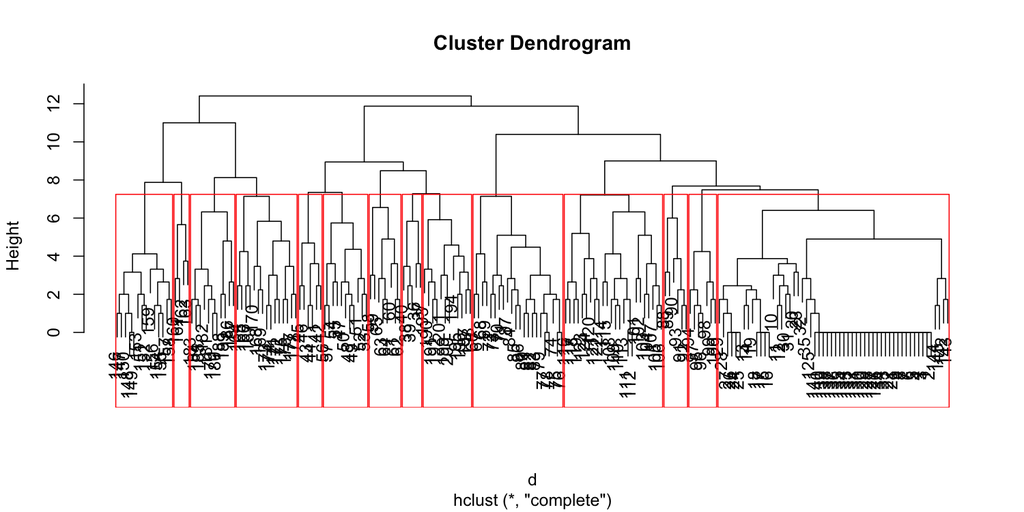

```r
d <- dist(cl)
hc <- hclust(d)

groups <- cutree(hc, k = 14)
plot(hc)
rect.hclust(hc,  border="red",k=14)
```

### Low level image processing

[figure not shown]

```r
## source("http://bioconductor.org/biocLite.R")
## biocLite("EBImage")

library(EBImage)
f = system.file("images", "lena.png", package="EBImage")
lena = readImage(f)
grid.raster(lena)
```

### Viewing image data

```r
print(lena)
```

```
Image
  colorMode    : Grayscale
  storage.mode : double
  dim          : 512 512
  frames.total : 1
  frames.render: 1

imageData(object)[1:5,1:6]
          [,1]      [,2]      [,3]      [,4]      [,5]      [,6]
[1,] 0.5372549 0.5372549 0.5372549 0.5372549 0.5372549 0.5490196
[2,] 0.5372549 0.5372549 0.5372549 0.5372549 0.5372549 0.5490196
[3,] 0.5372549 0.5372549 0.5372549 0.5372549 0.5372549 0.5137255
[4,] 0.5333333 0.5333333 0.5333333 0.5333333 0.5333333 0.5098039
[5,] 0.5411765 0.5411765 0.5411765 0.5411765 0.5411765 0.5333333
```

### Algebraic operation with image

[figure not shown]

```r
lena1 <- lena + 0.5
grid.raster(lena1)
```

Increase in color means more light or white in color

[figure not shown]

```r
lena2 <- lena * 3
grid.raster(lena2)
```

Multiplication gets the difference multiplied which is causing the increased contrasts

### More about EBImage package

- More functions like `rotate()` `, flip()` `, translate()` and `filter2()`
  - details can be found in the package [vignette](http://www.bioconductor.org/packages/release/bioc/vignettes/EBImage/inst/doc/EBImage-introduction.pdf)

[figure not shown]

```r
fhi = matrix(1, nc=3, nr=3)
fhi[2,2] = -8
lenafhi = filter2(lena, fhi)
grid.raster(lenafhi)
```

### Reading assignment and references

- Raster Images in R Graphics  
  http://journal.r-project.org/archive/2011-1/RJournal_2011-1_Murrell.pdf
- Introduction to EBImage, an image processing and analysis toolkit for R  
  http://www.bioconductor.org/packages/release/bioc/vignettes/EBImage/inst/doc/EBImage-introduction.pdf